[O’Hara on GitHub](https://github.com/oharac)

# Map vulnerability

Compiled on Sat Nov 20 08:27:09 2021 by ohara

```r
knitr::opts_chunk$set(echo = TRUE, message = FALSE, warning = FALSE)

library(raster)
library(oharac)
oharac::setup()
source(here('common_fxns.R'))
```

# 1 Summary

Apply vulnerability scores to AquaMaps species. Map out vulnerability to each stressor, first unweighted by species (each spp counts same), then unweighted by functional entity (each functional entity counts same), then weighted by functional vulnerability (FEs with higher FV are given greater weight).

# 2 Data

- AquaMaps
- Vulnerability Framework
- FishBase/SeaLifeBase

# 3 Methods

## 3.1 Unweighted, by species

Read in AquaMaps maps and vulnerability scores. Iterating over each stressor, calculate cell-by-cell mean, standard deviation.

To be determined:

- filter out low-occurrence species?
- preferred threshold?

```r
occurcells_thresh  <- 0
am_presence_thresh <- 0
am_spp_ids <- get_am_spp_info() %>%
  filter(occur_cells >= occurcells_thresh) %>%
  ### filter to spp with enough occurrences?
  select(am_sid, sciname) %>%
  distinct()

spp_vuln <- get_spp_vuln(gapfill = 'all')

am_vuln <- spp_vuln %>%
  select(species, stressor, score) %>%
  filter(!is.na(score)) %>%
  distinct() %>%
  inner_join(am_spp_ids, by = c('species' = 'sciname'))

excl <- get_am_spp_info() %>%
  filter(occur_cells >= occurcells_thresh) %>%
  filter(!sciname %in% spp_vuln$species)
### 2720 missing when vulnerability gapfilled to class;
### 6971 missing when gapfilled to order;
### 13241 missing when gapfilled to family...

table(excl$class)
```

```
##
##      actinopterygii         adenophorea            amphibia              anopla
##                   1                   3                   1                  10
##            anthozoa         aplacophora      appendicularia           arachnida
##                   1                  54                  14                   2
##          articulata          ascidiacea   bacillariophyceae    bicosoecophyceae
##                  55                 703                   1                   2
##            bivalvia        branchiopoda    bryopsidophyceae            calcarea
##                  67                   3                  63                  62
##  cephalaspidomorphi       cephalocarida     cephalochordata       chlorophyceae
##                   6                   1                  13                   1
##          clitellata compsopogonophyceae coscinodiscophyceae             cubozoa
##                  28                   1                   1                   5
##        demospongiae         dinophyceae          echinoidea              enopla
##                   9                   4                   1                   3
##       enteropneusta       equisetopsida       eucycliophora         eurotatoria
##                   3                   7                   2                   1
##     florideophyceae        foraminifera          gastropoda        gymnolaemata
##                 114                   1                  31                 303
##      hexactinellida         holocephali       holothuroidea            hydrozoa
##                  23                  49                   2                 581
##        inarticulata       magnoliopsida        malacostraca         maxillopoda
##                   7                   7                  28                 602
##         merostomata      monoplacophora        not assigned                nuda
##                   4                   3                 174                   3
##   oligohymenophorea           ostracoda palaeacanthocephala        phaeophyceae
##                   1                  38                   2                  64
##   phascolosomatidea          polychaeta      polyplacophora        polythalamea
##                  35                   2                 142                  81
##      priapulomorpha       pterobranchia            reptilia     rhodellophyceae
##                   5                   6                   1                   1
##       sarcopterygii          scaphopoda           scyphozoa         secernentea
##                   2                 374                  39                   1
##        sipunculidea         tentaculata           thaliacea         turbellaria
##                  57                   7                  18                  18
##         ulvophyceae
##                  33
```

```r
am_spp_cells <- get_am_spp_cells(occurcells_cut = occurcells_thresh,
                                 prob_cut = am_presence_thresh)
```

#### 3.1.0.1 Inclusion of species: vuln X am

When applying vulnerability scores at the species level, inclusion depends on species being accounted for both in AquaMaps and the vulnerability project. In this case, the number of included species is 29045.

```r
strs <- spp_vuln$stressor %>% unique() %>% sort()

out_stem <- here('_output/vuln_by_spp/vuln_by_spp_%s_%s.tif')
### unlink(list.files(here('_output/vuln_by_spp'), full.names = TRUE))

for(s in strs) {
  ### s <- strs[2]
  if(file.exists(sprintf(out_stem, s, 'mean')) &
     file.exists(sprintf(out_stem, s, 'sd'))) {
    message('Rasters exist for stressor ', s, '... skipping!')
    next()
  }
  message('processing mean/sd vulnerability by species to stressor: ', s)
  am_vuln_str <- am_vuln %>%
    filter(stressor == s)
  am_spp_vuln_cells <- am_spp_cells %>%
    oharac::dt_join(am_vuln_str, by = 'am_sid', type = 'inner')

  result_df <- am_spp_vuln_cells %>%
    filter(!is.na(score)) %>%
    group_by(loiczid) %>%
    summarize(score_mean = mean(score) %>% round(5),
              score_sd   = sd(score) %>% round(5),
              .groups = 'drop')

  rast_mean <- map_to_hcaf(result_df, which = 'score_mean')
  rast_sd   <- map_to_hcaf(result_df, which = 'score_sd')


  writeRaster(rast_mean, sprintf(out_stem, s, 'mean'), overwrite = TRUE)
  writeRaster(rast_sd,   sprintf(out_stem, s, 'sd'), overwrite = TRUE)
}
```

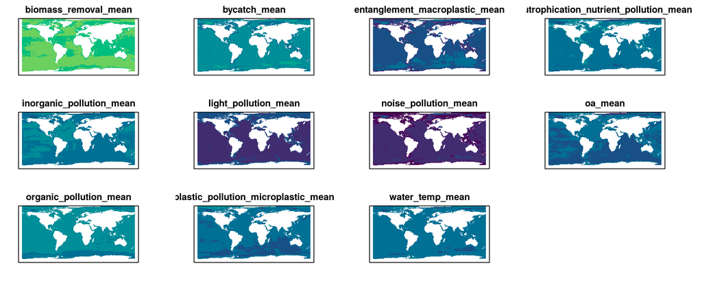

```r
focal_strs <- c('biomass', 'bycatch', 'plastic',
                'nutrient', 'oa', 'water_temp',
                'light', 'noise', 'organic') %>%
  paste0(collapse = '|')
mean_fs <- list.files(here('_output/vuln_by_spp'), pattern = 'mean', full.names = TRUE)
# sd_fs   <- list.files(here('_output/vuln_by_spp'), pattern = 'sd', full.names = TRUE)

mean_fs <- mean_fs[str_detect(basename(mean_fs), focal_strs)]

mean_stack <- raster::stack(mean_fs) %>%
  setNames(str_remove(names(.), 'vuln_by_spp_'))
# sd_stack   <- raster::stack(sd_fs) %>%
#   setNames(str_remove(names(.), 'vuln_by_spp_'))

map_cols <- hcl.colors(n = 10)

plot(mean_stack, zlim = c(0, 1), col = map_cols,
     legend = FALSE, axes = FALSE)
```

```r
# plot(sd_stack,   zlim = c(0, 1), legend = FALSE, axes = FALSE)
```

### 3.1.1 By FE, unweighted

```r
strs <- spp_vuln$stressor %>% unique() %>% sort()

out_stem <- here('_output/vuln_by_fe/vuln_by_fe_%s_%s.tif')
### unlink(list.files(here('_output/vuln_by_fe'), full.names = TRUE))

fe_df <- read_csv(here('_output/func_entities/species_fe.csv'))

am_vuln_fe <- am_vuln %>%
  oharac::dt_join(fe_df, by = 'species', type = 'inner') %>%
  select(am_sid, fe_id, stressor, score) %>%
  distinct()

for(s in strs) {
  ### s <- strs[1]
  if(file.exists(sprintf(out_stem, s, 'mean'))) {
    message('Rasters exist for stressor ', s, '... skipping!')
    next()
  }
  message('processing mean/sd vulnerability by species to stressor: ', s)

  am_vuln_str <- am_vuln_fe %>%
    filter(stressor == s)

  am_spp_vuln_cells <- am_spp_cells %>%
    oharac::dt_join(am_vuln_str, by = 'am_sid', type = 'inner')
  message('summarizing by FE in each cell...')
  result_df <- am_spp_vuln_cells %>%
    filter(!is.na(score)) %>%
    group_by(loiczid, fe_id) %>%
    ### first, summarize by FE per cell...
    summarize(score_mean1 = mean(score),
              # score_sd   = sd(score),
              .groups = 'drop')

  message('...then summarizing across all FEs in each cell...')
  result_df <- result_df %>%
    group_by(loiczid) %>%
    ### ... then average across all FEs
    summarize(score_mean = mean(score_mean1),
              # score_sd   = sqrt(sum(score_sd^2, na.rm = TRUE) / n()),
              # score_sd   = sd(score_mean1), ### this is deviation of mean among FEs
              .groups = 'drop')

  rast_mean <- map_to_hcaf(result_df, which = 'score_mean')
  # rast_sd   <- map_to_hcaf(result_df, which = 'score_sd')

  writeRaster(rast_mean, sprintf(out_stem, s, 'mean'), overwrite = TRUE)
  # writeRaster(rast_sd,   sprintf(out_stem, s, 'sd'), overwrite = TRUE)
}
```

#### 3.1.1.1 Inclusion of species: vuln X am X fe

When applying vulnerability scores at the functional entity level, species must be accounted for in AquaMaps, vulnerability scores, and functional entity traits. In this case, the number of included species is 21467. Looking at the intersection of AquaMaps and functional traits only, we include 21797.

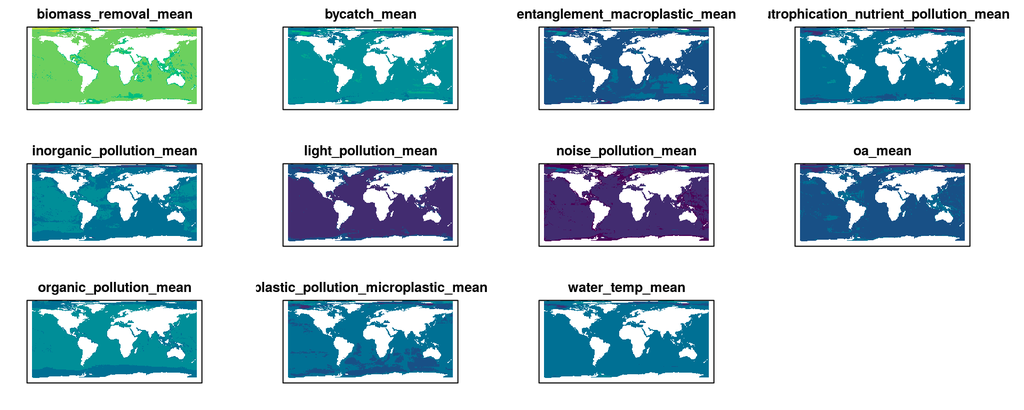

```r
mean_fs <- list.files(here('_output/vuln_by_fe'), pattern = 'mean', full.names = TRUE)
# sd_fs   <- list.files(here('_output/vuln_by_fe'), pattern = 'sd', full.names = TRUE)

mean_fs <- mean_fs[str_detect(basename(mean_fs), focal_strs)]

mean_stack <- raster::stack(mean_fs) %>%
  setNames(str_remove(names(.), 'vuln_by_fe_'))
# sd_stack   <- raster::stack(sd_fs) %>%
#   setNames(str_remove(names(.), 'vuln_by_fe_'))

plot(mean_stack, zlim = c(0, 1), col = map_cols,
     legend = FALSE, axes = FALSE)
```

```r
# plot(sd_stack,   zlim = c(0, 1), legend = FALSE, axes = FALSE)
```

### 3.1.2 By FE, FV-weighted

Here, calculate mean stressor vulnerability for each functional entity, along with the functional vulnerability of each entity using $\left(\frac{1}{2}\right)^{n-1}$ (so for an FE represented by one species, functional vuln = $\left(\frac{1}{2}\right)^{0}$ 1; for an FE represented by 5 spp, $\left(\frac{1}{2}\right)^{4}$ = .0625; for an FE represented by 10 spp, $\left(\frac{1}{2}\right)^{9}$ = .002 etc).

```r
strs <- spp_vuln$stressor %>% unique() %>% sort()

message('Calculating functional vulnerability by FE and cell...')

out_stem <- here('_output/vuln_by_fe_weighted/vuln_wt_by_fe_%s_%s.tif')

### unlink(list.files(here('_output/vuln_by_fe_weighted'), full.names = TRUE))

for(s in strs) {
  ### s <- strs[2]
  if(file.exists(sprintf(out_stem, s, 'mean'))) {
    message('Rasters exist for stressor ', s, '... skipping!')
    next()
  }

  message('processing mean/sd vulnerability by species to stressor: ', s)

  if(!exists('am_spp_cells_fv')) {
    am_spp_cells_fv <- am_spp_cells %>%
      oharac::dt_join(am_vuln_fe %>%
                        select(am_sid, fe_id) %>% distinct(),
                      by = 'am_sid', type = 'inner') %>%
      group_by(loiczid, fe_id) %>%
      mutate(nspp_fe = n(), ### only one observation per am_sid per cell
             fv = 0.5^(nspp_fe - 1)) %>%
      ungroup()
  }

  am_vuln_str <- am_vuln_fe %>%
    filter(stressor == s) %>%
    select(-fe_id) %>%
    distinct()
  am_spp_vuln_cells <- am_spp_cells_fv %>%
    oharac::dt_join(am_vuln_str, by = c('am_sid'), type = 'inner')

  message('summarizing by FE in each cell...')
  result_df <- am_spp_vuln_cells %>%
    filter(!is.na(score)) %>%
    group_by(loiczid, fe_id, fv, nspp_fe) %>%
    ### first, summarize by FE per cell...
    summarize(score_mean1 = mean(score),
              # score_sd   = sd(score),
              .groups = 'drop')

  message('...then summarizing weighted mean across all FEs in each cell...')
  result_df <- result_df %>%
    group_by(loiczid) %>%
    ### ... then average across all FEs
    summarize(score_mean = Hmisc::wtd.mean(score_mean1, weights = fv),
              # score_sd   = sqrt(sum(score_sd^2 * fv, na.rm = TRUE) / sum(fv)),
              # score_sd   = sqrt(Hmisc::wtd.var(score_mean1, weights = fv)),
                ### weighted std dev among mean scores for each FE
              n_spp      = sum(nspp_fe),
              .groups = 'drop')

  rast_mean <- map_to_hcaf(result_df, which = 'score_mean')
  # rast_sd   <- map_to_hcaf(result_df, which = 'score_sd')

  writeRaster(rast_mean, sprintf(out_stem, s, 'mean'), overwrite = TRUE)
  # writeRaster(rast_sd,   sprintf(out_stem, s, 'sd'), overwrite = TRUE)
}
```

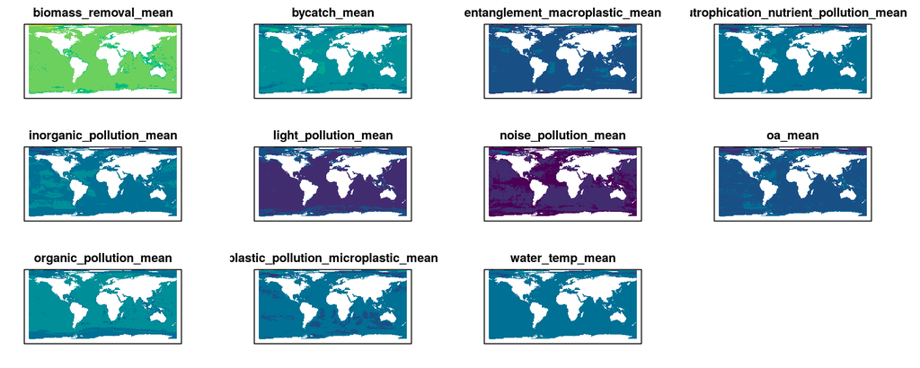

```r
mean_fs <- list.files(here('_output/vuln_by_fe_weighted'), pattern = 'mean', full.names = TRUE)
# sd_fs   <- list.files(here('_output/vuln_wt_by_fe'), pattern = 'sd', full.names = TRUE)

mean_fs <- mean_fs[str_detect(basename(mean_fs), focal_strs)]

mean_stack <- raster::stack(mean_fs) %>%
  setNames(str_remove(names(.), 'vuln_wt_by_fe_'))
# sd_stack   <- raster::stack(sd_fs) %>%
#   setNames(str_remove(names(.), 'vuln_wt_by_fe_'))

plot(mean_stack, zlim = c(0, 1), col = map_cols,
     legend = FALSE, axes = FALSE)
```

```r
# plot(sd_stack,   zlim = c(0, 1), legend = FALSE, axes = FALSE)
```